```python
import psycopg2
import geopandas as gpd
import matplotlib.pyplot as plt
import os, sys, csv
from IPython.display import HTML, display
from shapely import wkt
from time import time
from itertools import chain
import json
with open('psy_settings.json', 'r') as fid:
    con_kwds  = json.load(fid)
```

# Large dataset in CSV with malformed entries to PostGIS

This notebook documents the process of import a large (~44GB) dataset in csv format containing geographic data of nature observations into a PostGIS database.  
The data first came from the GBIF at https://www.gbif.org/dataset/38b4c89f-584c-41bb-bd8f-cd1def33e92f. Initially, I hoped to see whether bird migrations could be detected in this data from human observations.

The first step was to confirm the size and determine the number of rows in the dataset. Given the size, it was not possible to open in Excel, and was done by reading and discarding the rows with the csv reader in Python.

```
with open('artdatabanken.csv', 'r') as fid:
    reader = csv.reader(fid, delimiter="\t")

    names = next(reader)

    counter = 0
    for row in reader:
        counter += 1
```

Which resulted in a row count of 80'765'776 rows and 50 columns.

The column names in the data are

```python
with open("data/art_sub_small.csv", "r") as fid:
    names = next(csv.reader(fid, delimiter="\t"))
_ =  [display(HTML('<table><tr><td>{}</td></tr></table>'.format('</td><td>'.join(names[ii*10:ii*10+10])))) for ii in range(5)]
```

| gbifID | datasetKey | occurrenceID | kingdom | phylum | class | order | family | genus | species |
| --- | --- | --- | --- | --- | --- | --- | --- | --- | --- |

| infraspecificEpithet | taxonRank | scientificName | verbatimScientificName | verbatimScientificNameAuthorship | countryCode | locality | stateProvince | occurrenceStatus | individualCount |
| --- | --- | --- | --- | --- | --- | --- | --- | --- | --- |

| publishingOrgKey | decimalLatitude | decimalLongitude | coordinateUncertaintyInMeters | coordinatePrecision | elevation | elevationAccuracy | depth | depthAccuracy | eventDate |
| --- | --- | --- | --- | --- | --- | --- | --- | --- | --- |

| day | month | year | taxonKey | speciesKey | basisOfRecord | institutionCode | collectionCode | catalogNumber | recordNumber |
| --- | --- | --- | --- | --- | --- | --- | --- | --- | --- |

| identifiedBy | dateIdentified | license | rightsHolder | recordedBy | typeStatus | establishmentMeans | lastInterpreted | mediaType | issue |
| --- | --- | --- | --- | --- | --- | --- | --- | --- | --- |

With data of this size, we need some method of querying relevant entries to do meaningful work with it.  
I will load the data into a PostGIS database, which also support spatial functions and queries.

The first approach was to use COPY in psql with

```
\COPY
 artdatabanken(gbifid, datasetkey, occurrenceid, kingdom, phylum, class, "order", family, genus, species, infraspecificepithet, taxonrank, scientificname, verbatimscientificname, verbatimscientificnameauthorship, countrycode, locality, stateprovince, occurrencestatus, individualcount, publishingorgkey, decimallatitude, decimallongitude, coordinateuncertaintyinmeters, coordinateprecision, elevation, elevationaccuracy, depth, depthaccuracy, eventdate, day, month, year, taxonkey, specieskey, basisofrecord, institutioncode, collectioncode, catalognumber, recordnumber, identifiedby, dateidentified, license, rightsholder, recordedby, typestatus, establishmentmeans, lastinterpreted, mediatype, issue)
 FROM
 "data/artdatabanken.csv"
 CSV HEADER DELIMITER "\t";'
```

to a table "artdatabanken". This failed both with appropriate data types and with a table of text fields. At least parly because of unclose qutations causing the tab separators to be missed. Testing different quotation characters did not solve this, and instead opted for iterating over the data and clean and insert the data into the table. This would also allow me to catch any errors and handle these separately. Since the table was created with appropriate data types, the entries were checked so that they conformed to the requirements.

The process consisted of the following steps

1. Create table artdatabanken with appropriate data types and fields
2. Iterate over the rows of the data and clean these and insert into table artdatabanken.
3. Create tables for each of the kingdoms
4. Create geometry column from lon/lat data
5. Drop lon/lat columns and kingdom since all fields are equal for space
6. Drop unnecessary fields from artdatabanken table which can act as a key table

```python
def create_table(table_name, cols, dtypes, con, cur):

    # Get all table names
    cur.execute("select relname from pg_class where relkind='r' and relname !~ '^(pg_|sql_)';")
    tables = cur.fetchall()
    if table_name in list(chain.from_iterable(tables)):  # flatten
        cur.execute("drop table " + table_name)

    col_creation = [col + " " +  dtype + ", " for col, dtype in zip(cols, dtypes)]
    col_creation[-1] = col_creation[-1].strip(", ")

    sql_table_creation = "CREATE TABLE {}({})".format(table_name, "".join(col_creation))
    cur.execute(sql_table_creation)
    con.commit()


def my_insertion_method(csv_name, table_name, con, cur, cols, dtypes, err_log="error.log", err_csv="error.csv"):

    with open(csv_fname) as fid, open(err_log, "w") as error_log, open(err_csv, "w") as error_csv:

        reader = csv.reader(fid, delimiter="\t", quoting=csv.QUOTE_NONE)

        names = next(reader)
        colnames = [name.lower().replace("order", "ordercol") for name in names]  #rename order column

        col_indexes = [colnames.index(col) for col in cols]
        int_indexes = [ii for ii, dtype in enumerate(dtypes) if dtype == "int"]

        indexes = [colnames.index(col) for col in cols]
        table_columns = [colnames[ii] for ii in col_indexes]

        error_writer = csv.writer(error_csv, delimiter = "\t")
        error_writer.writerow(colnames)

        for ii, row in enumerate(reader):
            # Clean each row from quotation marks and apostrophes
            values = [row[index].replace("'", "").replace("`", "").replace("\"", "") for index in indexes]

            # Truncate all values which go to fields with int type
            for int_index in int_indexes:
                values[int_index] = values[int_index].split(".", 1)[0] if values[int_index] else '-1'

            # Try to insert and catch errors and write problematic rows to a separate file
            try:
                insert_statement = f"INSERT INTO {table_name}(" + ", ".join(table_columns) + ") VALUES ('{}')".format("', '".join(values))
                cur.execute("SAVEPOINT my_savepoint")
                cur.execute(insert_statement)

            except Exception as e:
                print(e)
                error_log.write("\n\nFailed to insert row \n\t{} \nwith Error \n\t{}".format(row, e))
                error_writer.writerow(row)
                cur.execute("ROLLBACK TO SAVEPOINT my_savepoint")

            finally:
                cur.execute("RELEASE SAVEPOINT my_savepoint")

    con.commit()
    return

csv_fname = "data/artdatabanken.csv"
table_name = "artdatabanken"


cols = ['gbifid',
    'kingdom',
    'phylum',
    'class',
    'ordercol',
    'family',
    'verbatimscientificname',
    'decimallatitude',
    'decimallongitude',
    'coordinateuncertaintyinmeters',
    'eventdate'
    ]

dtypes = ['bigint PRIMARY KEY',
    'VARCHAR',
    'VARCHAR',
    'VARCHAR',
    'VARCHAR',
    'VARCHAR',
    'VARCHAR',
    'DOUBLE PRECISION',
    'DOUBLE PRECISION',
    'int',
    'TIMESTAMP'
    ]

con = psycopg2.connect(**con_kwds, database='artdatabanken')
cur = con.cursor()

create_table(table_name, cols, dtypes, con, cur)
my_insertion_method(csv_fname, table_name, con, cur, cols, dtypes)
```

This method was sucessful and only resulted in one failed insertion.  
The row causing the failure was written to the csv `errors.csv` and the error output by postgres was written to `error.log` for further inspection. Without error handling this would have caused a failure of the total insertion.

According to the log file, the insertion failed because the row was missing an entry for the `eventdate`-column.  
Something which could have been checked before the insertion, but this shows that the approach can catch errors without breaking the process.

```
Failed to insert row
    ['1493233058', '38b4c89f-584c-41bb-bd8f-cd1def33e92f', 'urn:lsid:artportalen.se:Sighting:61036656', 'Animalia', 'Arthropoda', 'Insecta', 'Lepidoptera', 'Tortricidae', 'Rhyacionia', 'Rhyacionia pinicolana', '', 'SPECIES', 'Rhyacionia pinicolana (Doubleday, 1849)', 'Rhyacionia pinicolana', '(Doubleday, 1849)', 'SE', 'Framnäs, Bollnäs', '', 'PRESENT', '', 'b8323864-602a-4a7d-9127-bb903054e97d', '61.365816', '16.396104', '500.0', '', '', '', '', '', '', '', '', '', '1739337', '1739337', 'HUMAN_OBSERVATION', 'ArtDatabanken', 'Artportalen', '101186632', '', '', '', 'CC0_1_0', 'Hans Höglund', 'Hans Höglund', '', '', '2021-03-11T18:15:28.807Z', '', 'RECORDED_DATE_UNLIKELY;GEODETIC_DATUM_ASSUMED_WGS84']
with Error
    invalid input syntax for type timestamp: ""
LINE 1: ...Rhyacionia pinicolana', '61.365816', '16.396104', '500', '')
```

This could be handled by inserting a NULL value to this entry.

The full row is:

```python
pd.read_csv('data/error.csv', delimiter="\t").T
```

|  | 0 |
| --- | --- |
| gbifid | 1493233058 |
| datasetkey | 38b4c89f-584c-41bb-bd8f-cd1def33e92f |
| occurrenceid | urn:lsid:artportalen.se:Sighting:61036656 |
| kingdom | Animalia |
| phylum | Arthropoda |
| class | Insecta |
| ordercol | Lepidoptera |
| family | Tortricidae |
| genus | Rhyacionia |
| species | Rhyacionia pinicolana |
| infraspecificepithet | NaN |
| taxonrank | SPECIES |
| scientificname | Rhyacionia pinicolana (Doubleday, 1849) |
| verbatimscientificname | Rhyacionia pinicolana |
| verbatimscientificnameauthorship | (Doubleday, 1849) |
| countrycode | SE |
| locality | Framnäs, Bollnäs |
| stateprovince | NaN |
| occurrencestatus | PRESENT |
| individualcount | NaN |
| publishingorgkey | b8323864-602a-4a7d-9127-bb903054e97d |
| decimallatitude | 61.365816 |
| decimallongitude | 16.396104 |
| coordinateuncertaintyinmeters | 500.0 |
| coordinateprecision | NaN |
| elevation | NaN |
| elevationaccuracy | NaN |
| depth | NaN |
| depthaccuracy | NaN |
| eventdate | NaN |
| day | NaN |
| month | NaN |
| year | NaN |
| taxonkey | 1739337 |
| specieskey | 1739337 |
| basisofrecord | HUMAN_OBSERVATION |
| institutioncode | ArtDatabanken |
| collectioncode | Artportalen |
| catalognumber | 101186632 |
| recordnumber | NaN |
| identifiedby | NaN |
| dateidentified | NaN |
| license | CC0_1_0 |
| rightsholder | Hans Höglund |
| recordedby | Hans Höglund |
| typestatus | NaN |
| establishmentmeans | NaN |
| lastinterpreted | 2021-03-11T18:15:28.807Z |
| mediatype | NaN |
| issue | RECORDED_DATE_UNLIKELY;GEODETIC_DATUM_ASSUMED_... |

From the column `issue` we can read that the recorded date has been deemed "unlikely", and perhaps removed because of this.

After the main table `artdatabanken` was created, I created several smaller tables for each of the kingdoms.  
I did this by iterating over a list of the kingdoms, collected by gathering the unique values for the field in `artdatabanken`.

At the same time, I create a geometry column and created the point geometries with the PostGIS functioni `ST_MakePoint`. This means that we can remove the old columns with the longitude and latitude.  
Normally, this might not be so important. But with the number of rows, removing a column of numeric values has a noticeable impact on the table size. We can also remove the kingdom field since all entries are the same.

Finally, a full vacuum is done to reclaim the space released with the table alterations.

Running this process took a bit of time.

```python
def create_subtables(table, kingdom, con, cur, commit=True, vacuum=True):
    def execute_sql(sql):
        cur.execute(sql)
        if commit:
            con.commit()

    print("Creating table {}".format(table))

    sql = """
    CREATE TABLE Bacteria AS(
        SELECT * FROM artdatabanken WHERE kingdom LIKE '{}'
    )
    """.format(table)
    execute(sql)

    print("Dropping columns in table ", table)

    sql = """
    ALTER TABLE {}
    ADD COLUMN geom geometry(Point, 4326)
    """.format(table)
    execute_sql(sql)

    sql = """
    UPDATE {}
    SET geom = ST_SetSRID(ST_MakePoint(decimallongitude, decimallatitude), 4326)
    """
    execute_sql(sql)


    sql = """
    ALTER TABLE {}
    DROP COLUMN decimallongitude,
    DROP COLUMN decimallatitude,
    DROP COLUMN kingdom
    """.format(table)
    execute_sql(sql)

    if vacuum:
        old_isolation_level = con.isolation_level
        con.set_isolation_level(0)

        sql = """
        VACUUM FULL {}
        """.format(table)
        execute_sql(sql)

        con.set_isolation_level(old_isolation_level)

    print("Done with table", table)


con = psycopg2.connect(**con_kwds, database='artdatabanken')
cur = con.cursor()

table_names = [
    "Bacteria",
    "Viruses",
    "incertae sedis",
    "Fungi",
    "Chromista",
    "Animalia",
    "Plantae",
    "Protozoa"
              ]

table_names = [
    "Bacteria",
    "Viruses",
    "incertae",
    "Fungi",
    "Chromista",
    "Animalia",
    "Plantae",
    "Protozoa"
              ]

for table, kingdom in zip(table_names, kingdoms):
    create_subtables(table, kingdom, con, cur)

con.close()
```

Now that the data is in a database which we can query from we can select only the relevant data and start to answer questions.

I will study at birds, and first create a new table with all birds entries in the table `Animalia` for simplicity.

```
CREATE TABLE birds AS(
    SELECT * FROM Animalia WHERE class Like Aves;
    )
```

```python
con = psycopg2.connect(**con_kwds, database='artdatabanken')
cur = con.cursor()
gpd.GeoDataFrame.from_postgis("SELECT * FROM birds LIMIT 10", con)
```

|  | gbifid | family | verbatimscientificname | coordinateuncertaintyinmeters | eventdate | geom |
| --- | --- | --- | --- | --- | --- | --- |
| 0 | 2272830545 | Motacillidae | Motacilla alba | 295 | 2019-06-08 05:45:00 | POINT (13.14755 57.82147) |
| 1 | 2273017991 | Scolopacidae | Actitis hypoleucos | 555 | 2019-06-19 00:00:00 | POINT (14.28131 55.96149) |
| 2 | 2273646273 | Motacillidae | Anthus trivialis | 300 | 2019-06-26 09:00:00 | POINT (12.37015 57.56002) |
| 3 | 2273736281 | Fringillidae | Carpodacus erythrinus | 1482 | 2017-05-13 00:00:00 | POINT (16.46042 59.39140) |
| 4 | 2295165471 | Corvidae | Corvus corone cornix | 1000 | 2019-07-06 00:00:00 | POINT (13.65306 55.61721) |
| 5 | 2336825322 | Scolopacidae | Tringa totanus | 60 | 2019-08-14 00:00:00 | POINT (12.81221 55.37842) |
| 6 | 2365799559 | Hirundinidae | Hirundo rustica | 500 | 2019-08-20 19:30:00 | POINT (17.85455 59.90265) |
| 7 | 2381972649 | Picidae | Picoides tridactylus | 5 | 2019-08-20 00:00:00 | POINT (17.41619 64.78065) |
| 8 | 2383022638 | Falconidae | Falco vespertinus | 334 | 2019-09-02 16:40:00 | POINT (17.17785 59.71744) |
| 9 | 2412875639 | Accipitridae | Accipiter nisus | 4276 | 2019-09-08 06:00:00 | POINT (12.00635 58.23194) |

For example, we can use this to get all observations of the Red-footed falcon in the database and show their spatial distribution.

We do this by querying the database for all entries where `verbatimscientificname` is `Falco vespertinus`.

```python
cur.execute("SELECT COUNT(*) FROM birds WHERE verbatimscientificname LIKE 'Falco vespertinus'")
print("Number of observations for Red-footed falcon: ", cur.fetchall())
```

[output not shown]

The Falco Vespertinus is also called the "Red-footed falcon".

[figure not shown]

To plot the spatial distribution of observation distribution, it is easiests to load the entries straight into a Geopanda DataFrame, which has support for PostGIS.

```python
import matplotlib.pyplot as plt
import contextily as cx

gdf_falco = gpd.GeoDataFrame.from_postgis("SELECT * FROM birds WHERE verbatimscientificname LIKE 'Falco vespertinus'", con)
gdf_falco["year"] = gdf_falco.eventdate.apply(lambda x: x.year)
```

[figure not shown]

```python
fig = plt.figure(figsize=(20, 20))

ax0 = plt.subplot2grid((1, 5), (0, 0), colspan=3)
ax1 = plt.subplot2grid((3, 5), (1, 3), colspan=2, rowspan=1)
ax = [ax0, ax1]


gdf_falco.to_crs("epsg:3857").plot(markersize = 10, ax = ax[0], alpha=0.5, cmap=plt.cm.RdBu_r, column="year")
cx.add_basemap(ax[0], source=cx.providers.Stamen.TonerLite)
counts = []
years = []
for year, frame in gdf_falco.groupby("year"):
    counts.append(len(frame.index))
    years.append(year)

xticks = np.arange(min(years), max(years)+1, 10)
ax[1].bar(years, counts, width=1, edgecolor="black", facecolor="grey", alpha=0.6)
ax[1].set_xticks(xticks)
ax[1].set_xticklabels(xticks, rotation=60)
ax[1].set(xlabel="Year", ylabel="Observations", title="Number of observations per year")
plt.show()
```

# Bird observations on Gotland

We can also start to do more interesting visualizations and spatial filtering.

I will show this by creating a density map of all observations on the island of Gotland.

To do this, we need to filter the point in `birds` by the extent of Gotland. Luckily, I already have data on municipality borders in a PostGIS database from a previous project that I can use.

Since there may be observations that are off shore, and there is an uncertainty in both the borders and in the observations, a buffer zone of 10 kilometers will be created of the coast of Gotland.  
All of these steps can be done easily in PostGIS, and returns all observations in the provided polygon.

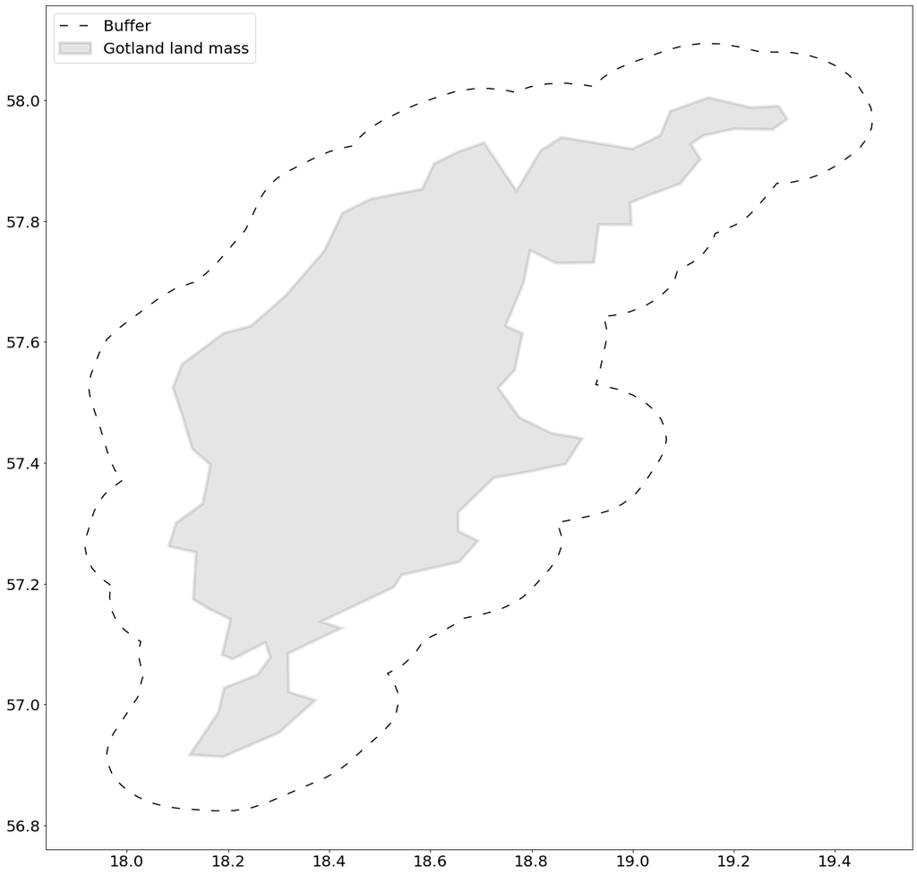

```python
con_swe = psycopg2.connect(**con_kwds, database='sverige')
cur_swe = con_swe.cursor()

# Get gotland boundary with buffer in WKT
sql = """
SELECT ST_Transform(geom, 4326) as geom, ST_AsText(
    ST_Transform(
        ST_Buffer(
            geom, 10000
        ),4326
        )
    ) AS buffer_wkt
    FROM kommun_sweref99tm_region WHERE knnamn LIKE 'Gotland'"""

gdf_gotland = gpd.GeoDataFrame.from_postgis(sql, con_swe)
gotland_buffer = wkt.loads(gdf_gotland.buffer_wkt.values[0]).exterior.xy
con_swe.close()


fig, ax = plt.subplots(figsize=(20, 20))
ax.fill(xy[:,0][0], xy[:,1][0], c = 'k', alpha=0.1, edgecolor='k', lw=4, label="Gotland land mass")
ax.plot(*gotland_buffer, c='k', ls='--', dashes=(7, 10), label='Buffer')
ax.legend()
```

```python
con_gbif = psycopg2.connect(**con_kwds, database='artdatabanken')
cur_gbif = con_gbif.cursor()

count_gotland_birds = """
SELECT COUNT(*) FROM birds WHERE ST_Intersects(birds.geom, ST_GeometryFromText('{}', 4326))
""".format(gdf_gotland["buffer_wkt"].values[0])

t0 = time()
cur_gbif.execute(count_gotland_birds)
execution_time = time() - t0

count = cur_gbif.fetchall()[0][0]

print("Execute time: ", execution_time)
print("Observation count: ", count)
```

```
Execute time:  77.02526307106018
Observation count:  1359155
```

There are ~1.3 million observations on Gotland in the dataset. Even though this is a lot, we can load it directly into a Geodataframe from the database.

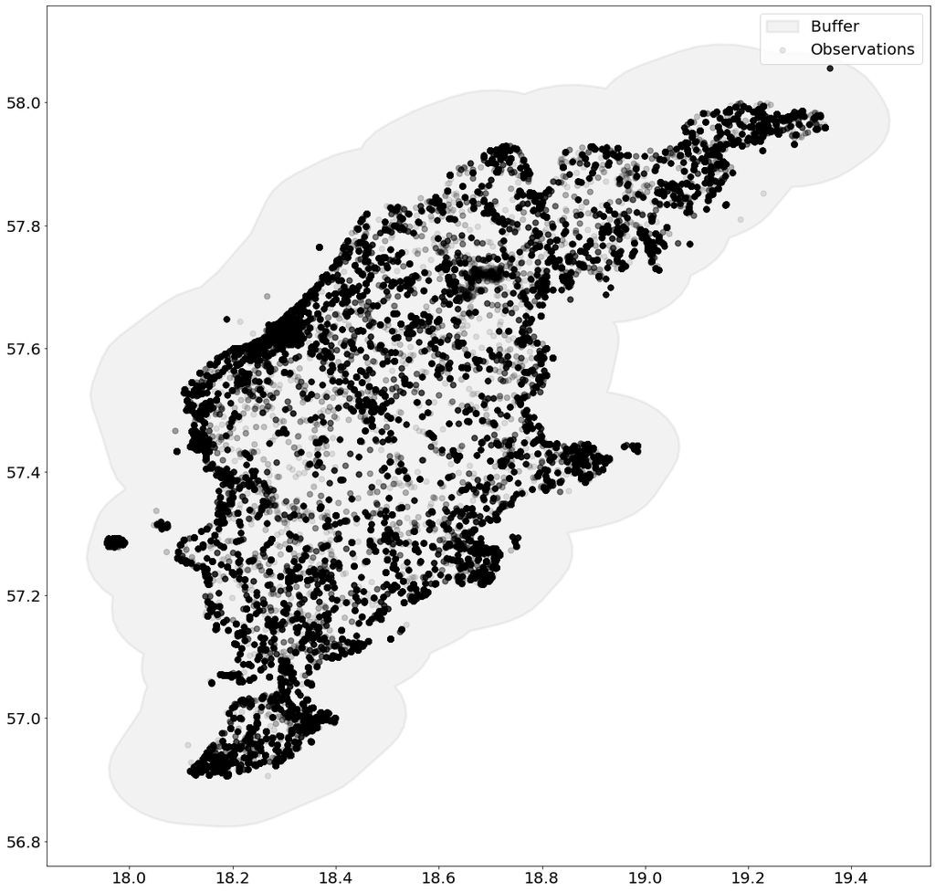

```python
sql_birds_gotland = """
SELECT verbatimscientificname, geom, eventdate FROM birds WHERE ST_Intersects(birds.geom, ST_GeometryFromText('{}', 4326))
""".format(gdf_gotland["buffer_wkt"].values[0])

gdf_birds_gotland = gpd.GeoDataFrame.from_postgis(sql_birds_gotland, con_gbif)

xs = gdf_birds_gotland.geometry.x
ys = gdf_birds_gotland.geometry.y

fig, ax = plt.subplots(figsize = (20, 20))


ax.fill(*gotland_buffer, 'k', alpha=0.05, edgecolor='k', lw=3, label="Buffer")
ax.scatter(xs, ys, 50, alpha=0.1, color='k', label="Observations")
ax.legend(fontsize=20, loc='upper right')
```

## Kernel density estimation

To show the distribution of observations a heatmap is made with sklearns kernel density estimator

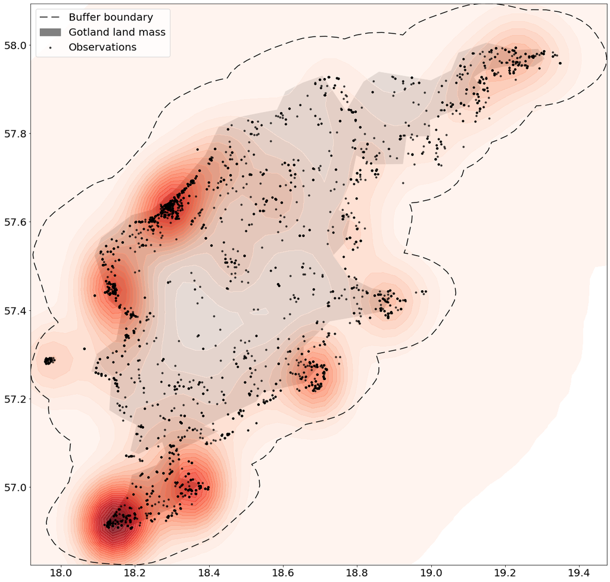

```python
from sklearn.neighbors import KernelDensity

data = np.vstack([xs, ys]).T

ind = np.random.choice(data.shape[0], 10000)
data_sub = data[ind]
X_train = data_sub*np.pi/180

kde = KernelDensity(bandwidth=0.001, metric='haversine', kernel='gaussian', algorithm='ball_tree')
kde.fit(X_train)

buffer = wkt.loads(gdf_gotland["buffer_wkt"].values[0])
xmin, ymin, xmax, ymax = buffer.bounds

xgrid = np.linspace(xmin, xmax)
ygrid = np.linspace(ymin, ymax)

X, Y = np.meshgrid(xgrid, ygrid)

xy = np.vstack((X.ravel(), Y.ravel())).T
xy *= np.pi/180

z = np.exp(kde.score_samples(xy))

Z = z.reshape(X.shape)

fig, ax = plt.subplots(figsize=(20, 20))
levels = np.linspace(1e-10, Z.max(), 25)

ax.plot(*gotland_buffer, 'k', ls='--', dashes=(10, 5), label="Buffer boundary")
ax.fill(*gdf_gotland.geometry.values[0].geoms[0].exterior.xy, zorder=0, label="Gotland land mass", color="grey")
ax.contourf(X, Y, Z, levels=levels, cmap=plt.cm.Reds, alpha=0.8)
ax.scatter(data_sub[:,0], data_sub[:,1], 10, 'k', alpha=0.7, label="Observations")
ax.legend()
```